# HW 2

Author

Mitchell Anderson

```r
#installing package and bringing data into environment
library(nycflights13)
library(dplyr)
library(tidyverse)
library(ggplot2)
library(leaflet)
weather<-weather
flights<-flights
planes<-planes
airports<-airports
airlines<-airlines
```

Question 1: Find the top 10 most popular destinations in the flights data. How many flights went to each?

```r
ten_top_destinations<-flights%>%
  count(dest,sort=TRUE)%>%
  slice_head(n=10)
ten_top_destinations
```

```
# A tibble: 10 × 2
   dest      n
   <chr> <int>
 1 ORD   17283
 2 ATL   17215
 3 LAX   16174
 4 BOS   15508
 5 MCO   14082
 6 CLT   14064
 7 SFO   13331
 8 FLL   12055
 9 MIA   11728
10 DCA    9705
```

This table displays the ten most popular destinations in the “flights” data set, ranked. The most popular destination was Chicago O’Hare with 17,283 flights and the tenth most popular destination was Ronald Reagan Washington National Airport with 9,705 flights.

Question 2: Create two new categorical variables in flights based on the departure time (dep_time), and arrival time (arr_time). These new variables should have four categories: “early morning” for 12am to 6am, “morning” for 6am to 12pm, “afternoon” for 12pm to 6pm, and “evening” for 6pm to 12am. Show barplots of both of these new variables. What percentage of flights were “red eye” flights? We’ll define these as flights that depart in “afternoon” or “evening” and arrive in “early morning” or “morning.”

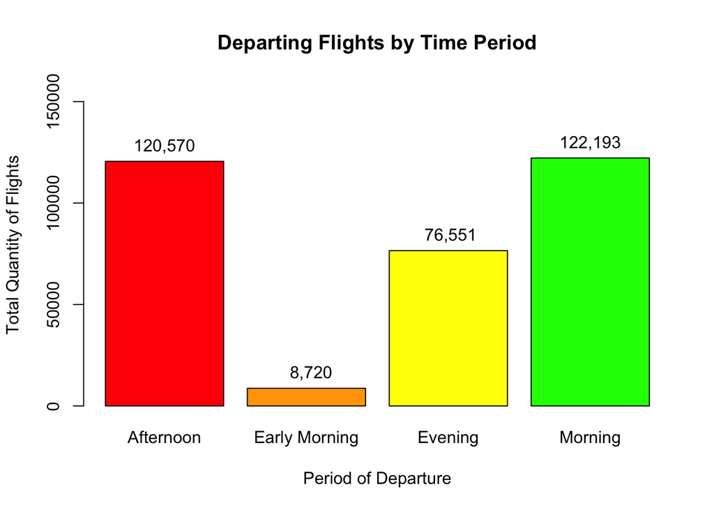

```r
#extract the arrival and departure times, converting them into the proper numerical form
flights<-flights %>%
  filter(!is.na(dep_time),!is.na(arr_time))%>%
  mutate(
    hour_of_departure=dep_time%/%100,
    hour_of_arrival=arr_time%/%100,
#create periods/buckets for departing flights based on time windows given, use case_when() to evaluate the conditions in the hour of departure and arrival times and assign them as TRUE or FALSE based on the parameters.
    departure_periods =case_when(
      hour_of_departure >= 0&hour_of_departure < 6~"Early Morning",
      hour_of_departure >= 6&hour_of_departure < 12~"Morning",
      hour_of_departure >= 12&hour_of_departure < 18~"Afternoon",
      hour_of_departure >= 18&hour_of_departure <= 23~"Evening",
      ),
#create periods/buckets for arriving flights based on time windows given
    arrival_periods = case_when(
      hour_of_arrival >= 0&hour_of_arrival < 6~"Early Morning",
      hour_of_arrival >= 6&hour_of_arrival < 12~"Morning",
      hour_of_arrival >= 12&hour_of_arrival < 18~"Afternoon",
      hour_of_arrival >= 18&hour_of_arrival <= 23~"Evening",
      ),overnight=arr_time<dep_time
  )

#create barplots to show the newly created "departure_periods" and "arrival_periods" variables
BPD<-table(na.omit(flights$departure_periods))
#create barplot,titles,labels,and y-axis counts on bars
#barplot for departure categories
barplot_departures<-barplot(
  BPD,
  main="Departing Flights by Time Period",
  xlab="Period of Departure",
  ylab="Total Quantity of Flights",
  col=c("red","orange","yellow","green"),
  ylim=c(0,max(BPD)*1.3)
)
text(x=barplot_departures,y=BPD,label=format(BPD,big.mark=","),pos=3,cex=1
)
```

[figure not shown]

```r
#barplot for arrival categories
BPA<-table(na.omit(flights$arrival_periods))
barplot_arrivals<-barplot(
  BPA,
  main="Arriving Flights by Time Period",
  xlab="Period of Arrival",
  ylab="Total Quantity of Flights",
  col=c("red","orange","yellow","green"),
  ylim=c(0,max(BPA)*1.3)
)
text(x=barplot_arrivals,y=BPA,label=format(BPD,big.mark=","),pos=3,cex=1
)
```

```r
#total number of red eyes
red_eyes <- flights %>%
  filter(
    departure_periods %in% c("Afternoon", "Evening") &
    (arrival_periods %in% c("Early Morning", "Morning") | overnight)
  )
#calculate percent
red_eye_percent<-(nrow(red_eyes)/nrow(flights))*100
#display percent value
cat("Percentage of Flights that were Red-Eye:",red_eye_percent,"%\n")
```

```
Percentage of Flights that were Red-Eye: 3.232306 %
```

The tables generated display the total amount of Departing and Arriving flights in the respective categories: “Afternoon”, “Early Morning”, “Evening”, and “Morning”. The percentage of flights that were red-eye is 3.23%.

Question 3: Where there any planes that flew for multiple airlines? If so, how many were there and which airlines did they fly for?

```r
#create object, filter by tail number, remove flights with missing tail no.
planes_multiple_carriers<-flights%>%
  filter(!is.na(tailnum))%>%
  group_by(tailnum)%>%
  #count the number of planes and the distinct carriers/airlines they flew for
  summarize(
    num_airlines=n_distinct(carrier),
    airlines=paste(sort(unique(carrier)),collapse=", ")
    )%>%
  filter(num_airlines > 1) %>%
  arrange(desc(num_airlines))

planes_multiple_carriers
```

```
# A tibble: 17 × 3
   tailnum num_airlines airlines
   <chr>          <int> <chr>
 1 N146PQ             2 9E, EV
 2 N153PQ             2 9E, EV
 3 N176PQ             2 9E, EV
 4 N181PQ             2 9E, EV
 5 N197PQ             2 9E, EV
 6 N200PQ             2 9E, EV
 7 N228PQ             2 9E, EV
 8 N232PQ             2 9E, EV
 9 N933AT             2 DL, FL
10 N935AT             2 DL, FL
11 N977AT             2 DL, FL
12 N978AT             2 DL, FL
13 N979AT             2 DL, FL
14 N981AT             2 DL, FL
15 N989AT             2 DL, FL
16 N990AT             2 DL, FL
17 N994AT             2 DL, FL
```

```r
tot_planes_multiple_carriers <- nrow(planes_multiple_carriers)
cat("Total Number of Planes that Flew for Multiple Carriers:",tot_planes_multiple_carriers,"\n")
```

```
Total Number of Planes that Flew for Multiple Carriers: 17
```

There were 17 planes that flew for multiple airlines/carriers. They flew on Endeavor Air Inc., Expressjet Airlines, Delta Airlines, and AirTran Airways Corporation.

The relationship adds new layers to the current diagram. ‘weather’ contains weather data respective to each airport being observed. There are many weather observations respective to each airport being examined. This means that an arrow should be drawn and added to the diagram that connects ‘weather’ to ‘airports’.

Question 5: In order to address our primary question, we want to prepare a tidy dataset (a single data frame). This will consist of information from the flights and weather data. The year, month, day, hour, and origin variables from weather provide almost enough information to give each observation a unique value. Create a new variable in the weather dataset by pasting together those 5 variables, then determine how many duplicated values there are and explain why.

```r
tidy_weather<-weather %>%
  mutate(weatherID=paste(year,month,day,hour,origin,sep = "_"))

duplicated_values<-sum(duplicated(tidy_weather$weatherID))
cat("Number of Duplicated Values:",duplicated_values,"\n")
```

```
Number of Duplicated Values: 3
```

```r
duplicates_list<-tidy_weather %>%
  count(weatherID)%>%
  filter(n > 1)%>%
  arrange(desc(n))

cat("Number of unique duplicated weatherID combinations:", nrow(duplicates_list),"\n\n")
```

```
Number of unique duplicated weatherID combinations: 3
```

```r
print(duplicates_list)
```

```
# A tibble: 3 × 2
  weatherID           n
  <chr>           <int>
1 2013_11_3_1_EWR     2
2 2013_11_3_1_JFK     2
3 2013_11_3_1_LGA     2
```

```r
flights_new<-flights %>%
  left_join(weather,by=c("origin","time_hour"))
```

Question 6: On this merged dataset, perform steps 2-5 of the EDA checklist presented in class. Remember the context provided by our primary question above.

```r
#EDA for flights_new$dep_delay, and weather conditions such as temp, dewpoint, humidity, wind direction/speed/gust, precipitation, pressure, and visibility.
glimpse(flights_new)
```

```
Rows: 328,063
Columns: 37
$ year.x            <int> 2013, 2013, 2013, 2013, 2013, 2013, 2013, 2013, 2013…
$ month.x           <int> 1, 1, 1, 1, 1, 1, 1, 1, 1, 1, 1, 1, 1, 1, 1, 1, 1, 1…
$ day.x             <int> 1, 1, 1, 1, 1, 1, 1, 1, 1, 1, 1, 1, 1, 1, 1, 1, 1, 1…
$ dep_time          <int> 517, 533, 542, 544, 554, 554, 555, 557, 557, 558, 55…
$ sched_dep_time    <int> 515, 529, 540, 545, 600, 558, 600, 600, 600, 600, 60…
$ dep_delay         <dbl> 2, 4, 2, -1, -6, -4, -5, -3, -3, -2, -2, -2, -2, -2,…
$ arr_time          <int> 830, 850, 923, 1004, 812, 740, 913, 709, 838, 753, 8…
$ sched_arr_time    <int> 819, 830, 850, 1022, 837, 728, 854, 723, 846, 745, 8…
$ arr_delay         <dbl> 11, 20, 33, -18, -25, 12, 19, -14, -8, 8, -2, -3, 7,…
$ carrier           <chr> "UA", "UA", "AA", "B6", "DL", "UA", "B6", "EV", "B6"…
$ flight            <int> 1545, 1714, 1141, 725, 461, 1696, 507, 5708, 79, 301…
$ tailnum           <chr> "N14228", "N24211", "N619AA", "N804JB", "N668DN", "N…
$ origin            <chr> "EWR", "LGA", "JFK", "JFK", "LGA", "EWR", "EWR", "LG…
```

[output cut: 24 more lines]

```r
colnames(flights_new)
```

```
 [1] "year.x"            "month.x"           "day.x"
 [4] "dep_time"          "sched_dep_time"    "dep_delay"
 [7] "arr_time"          "sched_arr_time"    "arr_delay"
[10] "carrier"           "flight"            "tailnum"
[13] "origin"            "dest"              "air_time"
[16] "distance"          "hour.x"            "minute"
[19] "time_hour"         "hour_of_departure" "hour_of_arrival"
[22] "departure_periods" "arrival_periods"   "overnight"
[25] "year.y"            "month.y"           "day.y"
[28] "hour.y"            "temp"              "dewp"
[31] "humid"             "wind_dir"          "wind_speed"
[34] "wind_gust"         "precip"            "pressure"
[37] "visib"
```

```r
dim(flights_new)
```

```
[1] 328063     37
```

```r
head(flights_new)
```

```
# A tibble: 6 × 37
  year.x month.x day.x dep_time sched_dep_time dep_delay arr_time sched_arr_time
   <int>   <int> <int>    <int>          <int>     <dbl>    <int>          <int>
1   2013       1     1      517            515         2      830            819
2   2013       1     1      533            529         4      850            830
3   2013       1     1      542            540         2      923            850
4   2013       1     1      544            545        -1     1004           1022
5   2013       1     1      554            600        -6      812            837
6   2013       1     1      554            558        -4      740            728
# ℹ 29 more variables: arr_delay <dbl>, carrier <chr>, flight <int>,
#   tailnum <chr>, origin <chr>, dest <chr>, air_time <dbl>, distance <dbl>,
#   hour.x <dbl>, minute <dbl>, time_hour <dttm>, hour_of_departure <dbl>,
#   hour_of_arrival <dbl>, departure_periods <chr>, arrival_periods <chr>,
#   overnight <lgl>, year.y <int>, month.y <int>, day.y <int>, hour.y <int>,
#   temp <dbl>, dewp <dbl>, humid <dbl>, wind_dir <dbl>, wind_speed <dbl>,
#   wind_gust <dbl>, precip <dbl>, pressure <dbl>, visib <dbl>
```

```r
tail(flights_new)
```

```
# A tibble: 6 × 37
  year.x month.x day.x dep_time sched_dep_time dep_delay arr_time sched_arr_time
   <int>   <int> <int>    <int>          <int>     <dbl>    <int>          <int>
1   2013       9    30     2237           2245        -8     2345           2353
2   2013       9    30     2240           2245        -5     2334           2351
3   2013       9    30     2240           2250       -10     2347              7
4   2013       9    30     2241           2246        -5     2345              1
5   2013       9    30     2307           2255        12     2359           2358
6   2013       9    30     2349           2359       -10      325            350
# ℹ 29 more variables: arr_delay <dbl>, carrier <chr>, flight <int>,
#   tailnum <chr>, origin <chr>, dest <chr>, air_time <dbl>, distance <dbl>,
#   hour.x <dbl>, minute <dbl>, time_hour <dttm>, hour_of_departure <dbl>,
#   hour_of_arrival <dbl>, departure_periods <chr>, arrival_periods <chr>,
#   overnight <lgl>, year.y <int>, month.y <int>, day.y <int>, hour.y <int>,
#   temp <dbl>, dewp <dbl>, humid <dbl>, wind_dir <dbl>, wind_speed <dbl>,
#   wind_gust <dbl>, precip <dbl>, pressure <dbl>, visib <dbl>
```

```r
str(flights_new)
```

```
tibble [328,063 × 37] (S3: tbl_df/tbl/data.frame)
 $ year.x           : int [1:328063] 2013 2013 2013 2013 2013 2013 2013 2013 2013 2013 ...
 $ month.x          : int [1:328063] 1 1 1 1 1 1 1 1 1 1 ...
 $ day.x            : int [1:328063] 1 1 1 1 1 1 1 1 1 1 ...
 $ dep_time         : int [1:328063] 517 533 542 544 554 554 555 557 557 558 ...
 $ sched_dep_time   : int [1:328063] 515 529 540 545 600 558 600 600 600 600 ...
 $ dep_delay        : num [1:328063] 2 4 2 -1 -6 -4 -5 -3 -3 -2 ...
 $ arr_time         : int [1:328063] 830 850 923 1004 812 740 913 709 838 753 ...
 $ sched_arr_time   : int [1:328063] 819 830 850 1022 837 728 854 723 846 745 ...
 $ arr_delay        : num [1:328063] 11 20 33 -18 -25 12 19 -14 -8 8 ...
 $ carrier          : chr [1:328063] "UA" "UA" "AA" "B6" ...
 $ flight           : int [1:328063] 1545 1714 1141 725 461 1696 507 5708 79 301 ...
 $ tailnum          : chr [1:328063] "N14228" "N24211" "N619AA" "N804JB" ...
 $ origin           : chr [1:328063] "EWR" "LGA" "JFK" "JFK" ...
 $ dest             : chr [1:328063] "IAH" "IAH" "MIA" "BQN" ...
```

[output cut: 23 more lines]

```r
summary(flights_new)
```

```
     year.x        month.x           day.x          dep_time    sched_dep_time
 Min.   :2013   Min.   : 1.000   Min.   : 1.00   Min.   :   1   Min.   : 500
 1st Qu.:2013   1st Qu.: 4.000   1st Qu.: 8.00   1st Qu.: 907   1st Qu.: 905
 Median :2013   Median : 7.000   Median :16.00   Median :1400   Median :1355
 Mean   :2013   Mean   : 6.564   Mean   :15.74   Mean   :1349   Mean   :1340
 3rd Qu.:2013   3rd Qu.:10.000   3rd Qu.:23.00   3rd Qu.:1744   3rd Qu.:1729
 Max.   :2013   Max.   :12.000   Max.   :31.00   Max.   :2400   Max.   :2359

   dep_delay          arr_time    sched_arr_time   arr_delay
 Min.   : -43.00   Min.   :   1   Min.   :   1   Min.   : -86.000
 1st Qu.:  -5.00   1st Qu.:1104   1st Qu.:1122   1st Qu.: -17.000
 Median :  -2.00   Median :1535   Median :1555   Median :  -5.000
 Mean   :  12.58   Mean   :1502   Mean   :1533   Mean   :   6.895
 3rd Qu.:  11.00   3rd Qu.:1940   3rd Qu.:1944   3rd Qu.:  14.000
 Max.   :1301.00   Max.   :2400   Max.   :2359   Max.   :1272.000
                                                 NA's   :717
   carrier              flight       tailnum             origin
 Length:328063      Min.   :   1   Length:328063      Length:328063
 Class :character   1st Qu.: 544   Class :character   Class :character
 Mode  :character   Median :1468   Mode  :character   Mode  :character
                    Mean   :1943
                    3rd Qu.:3413
                    Max.   :8500

     dest              air_time        distance        hour.x
 Length:328063      Min.   : 20.0   Min.   :  80   Min.   : 5.00
 Class :character   1st Qu.: 82.0   1st Qu.: 509   1st Qu.: 9.00
 Mode  :character   Median :129.0   Median : 888   Median :13.00
                    Mean   :150.7   Mean   :1049   Mean   :13.14
                    3rd Qu.:192.0   3rd Qu.:1391   3rd Qu.:17.00
                    Max.   :695.0   Max.   :4983   Max.   :23.00
                    NA's   :717
     minute        time_hour                   hour_of_departure
 Min.   : 0.00   Min.   :2013-01-01 05:00:00   Min.   : 0.00
 1st Qu.: 8.00   1st Qu.:2013-04-05 06:00:00   1st Qu.: 9.00
 Median :29.00   Median :2013-07-04 09:00:00   Median :14.00
 Mean   :26.24   Mean   :2013-07-03 17:28:06   Mean   :13.17
 3rd Qu.:44.00   3rd Qu.:2013-10-01 17:00:00   3rd Qu.:17.00
 Max.   :59.00   Max.   :2013-12-31 23:00:00   Max.   :24.00

```

[output cut: 25 more lines]

```
 Min.   : 0.000   Min.   :16.11    Min.   :0.00000   Min.   : 983.8
 1st Qu.: 6.905   1st Qu.:20.71    1st Qu.:0.00000   1st Qu.:1012.9
 Median :10.357   Median :24.17    Median :0.00000   Median :1017.6
 Mean   :11.061   Mean   :25.15    Mean   :0.00422   Mean   :1017.9
 3rd Qu.:14.960   3rd Qu.:27.62    3rd Qu.:0.00000   3rd Qu.:1022.9
 Max.   :42.579   Max.   :66.75    Max.   :1.21000   Max.   :1042.1
 NA's   :1606     NA's   :250461   NA's   :1528      NA's   :36224
     visib
 Min.   : 0.000
 1st Qu.:10.000
 Median :10.000
 Mean   : 9.289
 3rd Qu.:10.000
 Max.   :10.000
 NA's   :1528
```

```r
weather_factors <- flights_new %>%
  select(dep_delay,arr_delay,temp,dewp,humid,wind_dir,wind_speed,wind_gust, precip,pressure,visib)
#filter out NA values from arrival delays, departure delays, temp, dewpoint, humidity, wind direction, wind speed, wind gust, precipitation, pressure, and visibility
weather_factors<-weather_factors %>%
  filter(!is.na(arr_delay),!is.na(dep_delay))%>%
  filter(!is.na(temp),!is.na(dewp),!is.na(humid),!is.na(wind_dir), !is.na(wind_speed),!is.na(wind_gust),!is.na(precip),!is.na(pressure),!is.na(visib))
#basic summary statistics and EDA of weather factors
glimpse(weather_factors)
```

```
Rows: 72,734
Columns: 11
$ dep_delay  <dbl> 4, -6, -3, -2, -1, 0, 0, -8, -3, 13, -4, -6, -1, -1, 0, -8,…
$ arr_delay  <dbl> 20, -25, -14, 8, 31, -7, 12, -8, 16, 5, 1, 10, 14, -19, 48,…
$ temp       <dbl> 39.92, 39.92, 39.92, 39.92, 39.92, 39.92, 39.92, 39.92, 39.…
$ dewp       <dbl> 24.98, 24.98, 24.98, 24.98, 24.98, 24.98, 24.98, 24.98, 24.…
$ humid      <dbl> 54.81, 54.81, 54.81, 54.81, 54.81, 54.81, 54.81, 54.81, 54.…
$ wind_dir   <dbl> 250, 260, 260, 260, 260, 260, 260, 260, 260, 260, 260, 260,…
$ wind_speed <dbl> 14.96014, 16.11092, 16.11092, 16.11092, 16.11092, 16.11092,…
$ wind_gust  <dbl> 21.86482, 23.01560, 23.01560, 23.01560, 23.01560, 23.01560,…
$ precip     <dbl> 0, 0, 0, 0, 0, 0, 0, 0, 0, 0, 0, 0, 0, 0, 0, 0, 0, 0, 0, 0,…
$ pressure   <dbl> 1011.4, 1011.7, 1011.7, 1011.7, 1011.7, 1011.7, 1011.7, 101…
$ visib      <dbl> 10, 10, 10, 10, 10, 10, 10, 10, 10, 10, 10, 10, 10, 10, 10,…
```

```r
colnames(weather_factors)
```

```
 [1] "dep_delay"  "arr_delay"  "temp"       "dewp"       "humid"
 [6] "wind_dir"   "wind_speed" "wind_gust"  "precip"     "pressure"
[11] "visib"
```

```r
dim(weather_factors)
```

```
[1] 72734    11
```

```r
head(weather_factors)
```

```
# A tibble: 6 × 11
  dep_delay arr_delay  temp  dewp humid wind_dir wind_speed wind_gust precip
      <dbl>     <dbl> <dbl> <dbl> <dbl>    <dbl>      <dbl>     <dbl>  <dbl>
1         4        20  39.9  25.0  54.8      250       15.0      21.9      0
2        -6       -25  39.9  25.0  54.8      260       16.1      23.0      0
3        -3       -14  39.9  25.0  54.8      260       16.1      23.0      0
4        -2         8  39.9  25.0  54.8      260       16.1      23.0      0
5        -1        31  39.9  25.0  54.8      260       16.1      23.0      0
6         0        -7  39.9  25.0  54.8      260       16.1      23.0      0
# ℹ 2 more variables: pressure <dbl>, visib <dbl>
```

```r
tail(weather_factors)
```

```
# A tibble: 6 × 11
  dep_delay arr_delay  temp  dewp humid wind_dir wind_speed wind_gust precip
      <dbl>     <dbl> <dbl> <dbl> <dbl>    <dbl>      <dbl>     <dbl>  <dbl>
1        29        22  66.0  54.0  65.1       40       16.1      21.9      0
2        -4         1  66.0  54.0  65.1       40       16.1      21.9      0
3         1        14  66.0  54.0  65.1       40       16.1      21.9      0
4        -8         2  66.0  54.0  65.1       40       16.1      21.9      0
5        33        29  66.0  54.0  65.1       40       16.1      21.9      0
6        20        29  66.0  54.0  65.1       40       16.1      21.9      0
# ℹ 2 more variables: pressure <dbl>, visib <dbl>
```

```r
str(weather_factors)
```

```
tibble [72,734 × 11] (S3: tbl_df/tbl/data.frame)
 $ dep_delay : num [1:72734] 4 -6 -3 -2 -1 0 0 -8 -3 13 ...
 $ arr_delay : num [1:72734] 20 -25 -14 8 31 -7 12 -8 16 5 ...
 $ temp      : num [1:72734] 39.9 39.9 39.9 39.9 39.9 ...
 $ dewp      : num [1:72734] 25 25 25 25 25 ...
 $ humid     : num [1:72734] 54.8 54.8 54.8 54.8 54.8 ...
 $ wind_dir  : num [1:72734] 250 260 260 260 260 260 260 260 260 260 ...
 $ wind_speed: num [1:72734] 15 16.1 16.1 16.1 16.1 ...
 $ wind_gust : num [1:72734] 21.9 23 23 23 23 ...
 $ precip    : num [1:72734] 0 0 0 0 0 0 0 0 0 0 ...
 $ pressure  : num [1:72734] 1011 1012 1012 1012 1012 ...
 $ visib     : num [1:72734] 10 10 10 10 10 10 10 10 10 10 ...
```

```r
summary(weather_factors)
```

```
   dep_delay        arr_delay            temp             dewp
 Min.   :-23.00   Min.   :-74.000   Min.   : 12.02   Min.   :-9.94
 1st Qu.: -5.00   1st Qu.:-16.000   1st Qu.: 37.94   1st Qu.:17.06
 Median : -1.00   Median : -4.000   Median : 51.08   Median :28.94
 Mean   : 12.29   Mean   :  7.287   Mean   : 53.62   Mean   :32.50
 3rd Qu.: 11.00   3rd Qu.: 14.000   3rd Qu.: 68.00   3rd Qu.:48.92
 Max.   :797.00   Max.   :783.000   Max.   :100.04   Max.   :75.02
     humid          wind_dir       wind_speed       wind_gust
 Min.   :13.95   Min.   : 10.0   Min.   : 4.603   Min.   :16.11
 1st Qu.:35.80   1st Qu.:220.0   1st Qu.:12.659   1st Qu.:20.71
 Median :44.16   Median :280.0   Median :16.111   Median :24.17
 Mean   :46.75   Mean   :253.9   Mean   :16.523   Mean   :24.91
 3rd Qu.:54.77   3rd Qu.:310.0   3rd Qu.:19.563   3rd Qu.:27.62
 Max.   :96.85   Max.   :360.0   Max.   :39.127   Max.   :66.75
     precip            pressure          visib
 Min.   :0.000000   Min.   : 983.8   Min.   : 0.120
 1st Qu.:0.000000   1st Qu.:1010.8   1st Qu.:10.000
 Median :0.000000   Median :1015.4   Median :10.000
 Mean   :0.001352   Mean   :1015.6   Mean   : 9.803
 3rd Qu.:0.000000   3rd Qu.:1020.4   3rd Qu.:10.000
 Max.   :0.530000   Max.   :1040.4   Max.   :10.000
```

```r
#correlation analysis between the different weather factors in relation to arrivals and departures
correlations<-weather_factors%>%
  summarize(across(temp:visib,~cor(.,dep_delay,use= "complete.obs"),.names="departure_correlations_{col}"))%>%
  bind_cols(weather_factors%>%
      summarize(across(temp:visib,~cor(.,arr_delay,use="complete.obs"),.names="arrival_correlations_{col}"))
  )%>%
  pivot_longer(everything(), names_to = "variable",values_to="correlation")%>%
  mutate(type=ifelse(str_detect(variable,"departure_"),"Departure Delay","Arrival Delay"),
         variable = str_remove(variable, "departure_correlations_|arrival_correlations_"))
print(correlations)
```

```
# A tibble: 18 × 3
   variable   correlation type
   <chr>            <dbl> <chr>
 1 temp            0.0612 Departure Delay
 2 dewp            0.101  Departure Delay
 3 humid           0.122  Departure Delay
 4 wind_dir       -0.0684 Departure Delay
 5 wind_speed      0.0210 Departure Delay
 6 wind_gust       0.0244 Departure Delay
 7 precip          0.0484 Departure Delay
 8 pressure       -0.0817 Departure Delay
 9 visib          -0.0975 Departure Delay
10 temp            0.0516 Arrival Delay
11 dewp            0.0997 Arrival Delay
12 humid           0.140  Arrival Delay
13 wind_dir       -0.0756 Arrival Delay
14 wind_speed      0.0306 Arrival Delay
15 wind_gust       0.0337 Arrival Delay
16 precip          0.0669 Arrival Delay
17 pressure       -0.0871 Arrival Delay
18 visib          -0.129  Arrival Delay
```

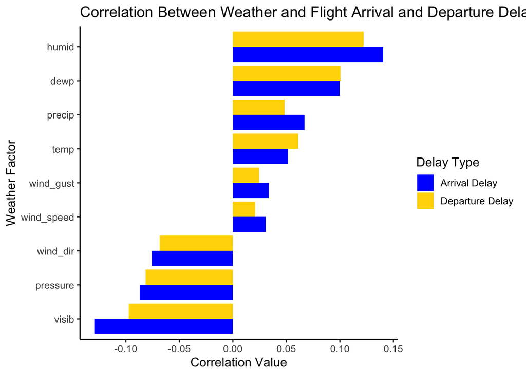

```r
#visualize correlations
ggplot(correlations,aes(x=reorder(variable,correlation),y = correlation,fill=type))+
  geom_col(position="dodge")+
  coord_flip()+
  labs(title="Correlation Between Weather and Flight Arrival and Departure Delays",x="Weather Factor",y="Correlation Value",fill="Delay Type")+scale_fill_manual(values=c("Departure Delay"="gold",
"Arrival Delay"="blue"))+
  theme_classic(base_size=12)
```

Question 7: Calculate the average departure delay for each day (Hint: think about which variables you need in order to do this!). Which day had the worst average length of delay for departures? Now calculate the averages by day and origin. Which airport had the worst single day for delays and when was it? Now calculate the averages by hour and origin. Which airport had the worst single hour for delays (and when was it)?

```r
#Calculate the average departure delay for each day
avg_daily_delay<-flights_new %>%
  group_by(year.x,month.x,day.x) %>%
  summarize(avg_departure_delay=mean(dep_delay,na.rm=TRUE),.groups="drop") %>%
  arrange(desc(avg_departure_delay))
#Which day had the worst average length of delay for departures?
worst_day<-avg_daily_delay%>%
  slice_max(avg_departure_delay,n=1)
print(worst_day)
```

```
# A tibble: 1 × 4
  year.x month.x day.x avg_departure_delay
   <int>   <int> <int>               <dbl>
1   2013       3     8                83.6
```

```r
#Calculate the averages by day and origin
daily_origin_delay<-flights_new %>%
  group_by(origin,year.x,month.x,day.x)%>%
  summarize(avg_departure_delay=mean(dep_delay,na.rm=TRUE),.groups="drop")%>%
  arrange(desc(avg_departure_delay))
#Which airport had the worst single day for delays and when was it
worst_airport_day_origin<-daily_origin_delay%>%
  slice_max(avg_departure_delay,n = 1)
print(worst_airport_day_origin)
```

```
# A tibble: 1 × 5
  origin year.x month.x day.x avg_departure_delay
  <chr>   <int>   <int> <int>               <dbl>
1 LGA      2013       3     8                106.
```

```r
#Now calculate the averages by hour and origin
hourly_origin_delay<-flights_new%>%
  group_by(origin,year.x,month.x,day.x,hour.x)%>%
  summarize(avg_departure_delay=mean(dep_delay,na.rm =TRUE),.groups="drop")%>%
  arrange(desc(avg_departure_delay))
#Which airport had the worst single hour for delays (and when was it)?
worst_airport_hour_origin<-hourly_origin_delay%>%
  slice_max(avg_departure_delay,n=1)
print(worst_airport_hour_origin)
```

```
# A tibble: 1 × 6
  origin year.x month.x day.x hour.x avg_departure_delay
  <chr>   <int>   <int> <int>  <dbl>               <dbl>
1 LGA      2013       7    22     18                310.
```

Question 8: Compute the average delay by destination, then add that information to the airports data frame. Make a map showing the spatial distribution of delays (you can make it however you like, but we recommend using either ggplot or leaflet). Use the color of the points to display the average delay for each airport.

```r
#Compute the average delay by destination
average_delay_destination<-flights_new%>%
  group_by(dest)%>%
  summarize(average_arrival_delay=mean(arr_delay,na.rm=TRUE),.groups="drop")
#Add the information to the airports data frame
average_delay_destination<-airports %>%
  left_join(average_delay_destination,by=c("faa"="dest"))

leaflet(average_delay_destination) %>%
  addTiles() %>%
  addCircleMarkers(lng = ~ lon, lat = ~lat,color=~ifelse(average_arrival_delay>0,"red","blue"),radius=~pmin(abs(average_arrival_delay)/5,10),popup=~paste0("<b>",name,"</b><br>Avg Delay: ",round(average_arrival_delay,1)," min"))%>%
  addLegend("bottomright", colors = c("blue", "red"),labels=c("On-Time/Early Arrival","Delayed Arrival"),title="Average Arrival Delays by Airport")
```

[interactive chart not shown]

Question 9: Finally, create as many plots and summary statistics as needed to answer the primary question above

```r
#create categories/buckets for temperatures seen in the columns that highlight temp, pressure, humidity, wind sp., visibility, and precipitation, regard for infinite and negative infinite values.
weather_delay_stat_summary<-flights_new%>%
  mutate(
    temp_category=cut(temp,breaks=c(-Inf,32,60,80,Inf),labels=c("Extremely Cold","Cool","Warm","Extremely Hot")),
    pressure_category=cut(pressure,breaks=c(-Inf,1000,1015,1030,Inf),labels=c("Low","Normal","High","Extremely High")),
    humidity_category=cut(humid,breaks=c(-Inf,40,70,Inf),labels =c("Low","Normal","High")),
    wind_speed_category=cut(wind_speed,breaks=c(-Inf,5,15,25,Inf),labels=c("Low","Calm","Blustery","Extremely Windy")),
    visibility_category=cut(visib, breaks=c(-Inf,2,5,10,Inf),labels=c("Low","Moderate","Good","Excellent")),
    precip_category=cut(precip,breaks=c(-Inf,0,0.1,0.5,Inf),labels=c("None","Light","Moderate","Heavy"))
  )
#find the average departure and arrival delay period for each weather factor
stat_summary_weather_category<-list(
  Temperature = weather_delay_stat_summary%>%
    group_by(temp_category)%>%
    summarize(avg_dep_delay=mean(dep_delay,na.rm=TRUE),avg_arr_delay=mean(arr_delay,na.rm=TRUE),n=n()),
   Pressure=weather_delay_stat_summary%>%
    group_by(pressure_category)%>%
    summarize(avg_dep_delay=mean(dep_delay,na.rm=TRUE),avg_arr_delay=mean(arr_delay,na.rm=TRUE),n=n()),
  Humidity=weather_delay_stat_summary%>%
    group_by(humidity_category)%>%
    summarize(avg_dep_delay=mean(dep_delay,na.rm=TRUE),avg_arr_delay=mean(arr_delay,na.rm=TRUE),n=n()),
  Wind_Speed=weather_delay_stat_summary%>%
    group_by(wind_speed_category)%>%
    summarize(avg_dep_delay=mean(dep_delay,na.rm=TRUE),avg_arr_delay=mean(arr_delay,na.rm=TRUE),n=n()),
  Visibility=weather_delay_stat_summary%>%
    group_by(visibility_category)%>%
    summarize(avg_dep_delay=mean(dep_delay,na.rm=TRUE),avg_arr_delay=mean(arr_delay,na.rm=TRUE),n=n()),
  Precipitation=weather_delay_stat_summary%>%
    group_by(precip_category)%>%
    summarize(avg_dep_delay=mean(dep_delay,na.rm=TRUE),avg_arr_delay=mean(arr_delay,na.rm=TRUE),n=n())
)

stat_summary_weather_category
```

```
$Temperature
# A tibble: 5 × 4
  temp_category  avg_dep_delay avg_arr_delay      n
  <fct>                  <dbl>         <dbl>  <int>
1 Extremely Cold          11.4          8.48  29495
2 Cool                    10.4          5.09 144259
3 Warm                    13.3          6.76 116517
4 Extremely Hot           19.7         13.1   36247
5 <NA>                    13.5          9.96   1545

$Pressure
# A tibble: 5 × 4
  pressure_category avg_dep_delay avg_arr_delay      n
  <fct>                     <dbl>         <dbl>  <int>
1 Low                       40.0         39.8     1944
2 Normal                    15.4         11.0   101221
3 High                       8.70         1.14  173307
4 Extremely High             5.63         0.186  15367
5 <NA>                      24.6         24.1    36224

$Humidity
# A tibble: 4 × 4
  humidity_category avg_dep_delay avg_arr_delay      n
  <fct>                     <dbl>         <dbl>  <int>
1 Low                        8.87          2.26  59336
2 Normal                     9.80          2.96 166260
3 High                      19.3          16.1  100922
4 <NA>                      13.5           9.96   1545

$Wind_Speed
# A tibble: 5 × 4
  wind_speed_category avg_dep_delay avg_arr_delay      n
  <fct>                       <dbl>         <dbl>  <int>
1 Low                          10.2          3.52  40624
2 Calm                         12.2          6.17 222376
3 Blustery                     14.9         10.9   58005
4 Extremely Windy              21.3         18.5    5452
5 <NA>                         13.0          8.92   1606

$Visibility
# A tibble: 4 × 4
  visibility_category avg_dep_delay avg_arr_delay      n
  <fct>                       <dbl>         <dbl>  <int>
1 Low                          27.8         32.7    9706
2 Moderate                     20.7         20.0   12318
3 Good                         11.8          5.53 304511
4 <NA>                         13.4          9.58   1528

$Precipitation
# A tibble: 5 × 4
  precip_category avg_dep_delay avg_arr_delay      n
  <fct>                   <dbl>         <dbl>  <int>
1 None                     11.3          5.05 305513
2 Light                    28.7         31.2   17308
3 Moderate                 40.4         44.1    3575
4 Heavy                    48.9         53.3     139
5 <NA>                     13.4          9.58   1528
```

From the statistical summary it can be seen that the weather condition that contributed to the most flight departure delays was precipitation and the weather condition that contributed to the most flight arrival delays was precipitation.